# Reproducible Research: Peer Assessment 1

## Loading and preprocessing the data

First step is to load and preprocess the data. Make sure the raw data .csv is extracted to the same folder of this markdown file.

The following script will do the following: * load the data from the CSV file * remove all incomplete values

```r
data.raw <- read.csv("activity.csv")
data <- data.raw[complete.cases(data.raw),]
```

## What is mean total number of steps taken per day?

The distribution of the steps taken per day:

```
## stat_bin: binwidth defaulted to range/30. Use 'binwidth = x' to adjust this.
```

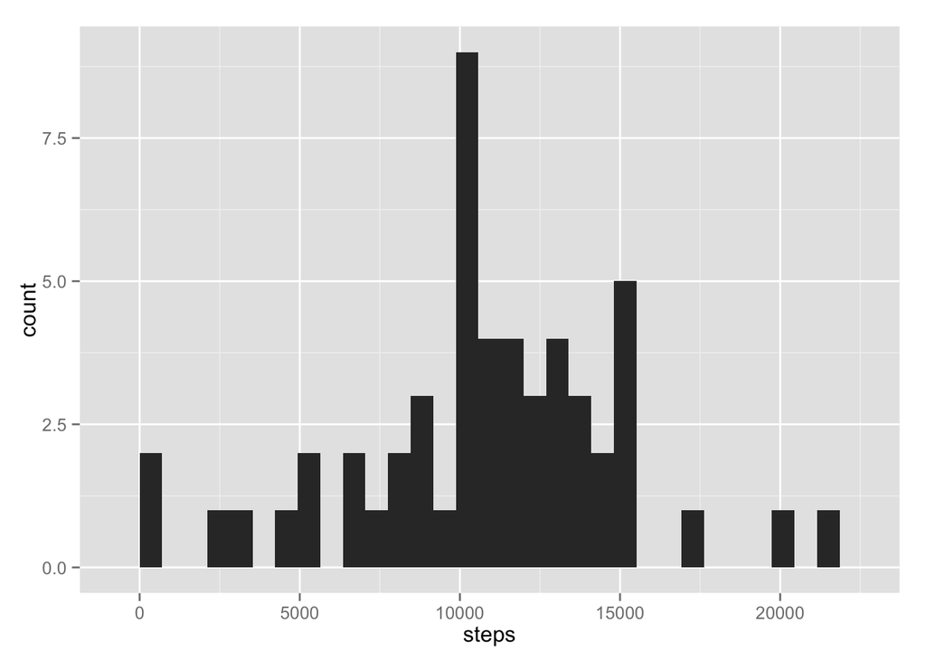

```r
library("ggplot2")
daily.steps <- aggregate(data$steps, list(data$date), sum, na.rm=TRUE)
names(daily.steps) = c("date","steps")
p1 <- ggplot(daily.steps, aes(x=steps))
p1 + geom_histogram()
```

The mean of the total number of steps taken per day:

```r
mean(daily.steps$steps)
```

```
## [1] 10766
```

The median of the total number of steps taken per day:

```r
median(daily.steps$steps)
```

```
## [1] 10765
```

## What is the average daily activity pattern?

To see the daily activity pattern, see the time series plot of the 5-minute interval (x-axis) and the average number of steps taken, averaged across all days (y-axis) below:

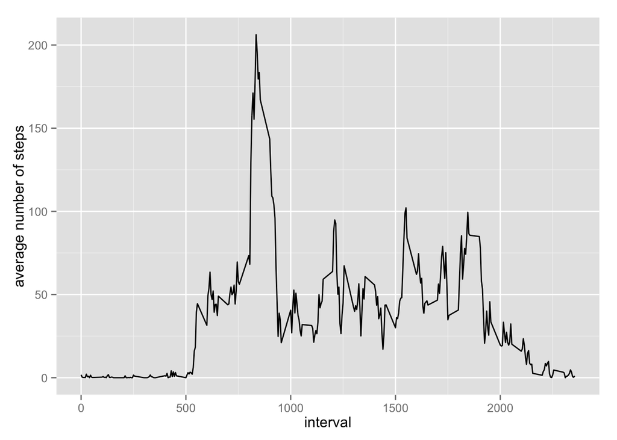

```r
avg.steps <- aggregate(data$steps, list(data$interval), mean, na.rm=TRUE)
names(avg.steps) = c("interval","steps")
p2 <- ggplot(avg.steps, aes(interval, steps))
p2 + geom_line() + xlab("interval") + ylab("average number of steps")
```

The following 5-minute interval contains the maximum number of steps:

```r
subset(avg.steps, steps == max(avg.steps$steps))$interval
```

```
## [1] 835
```

## Imputing missing values

1. The total number of missing values in the data set (i.e. the total number of rows with NAs) is:

```r
data.na <- subset(data.raw, is.na(data.raw$steps))
nrow(data.na)
```

```
## [1] 2304
```

2. Fill in the missing values by putting the average values of the number of steps for that interval:

```r
for (i in 1:nrow(data.na)) {
    data.na[i, c("steps")] = subset(avg.steps, interval == data.na[i,]$interval)$steps
}
```

3. The new histogram of the total number of steps taken each day after the missing values are imputed:

```
## stat_bin: binwidth defaulted to range/30. Use 'binwidth = x' to adjust this.
```

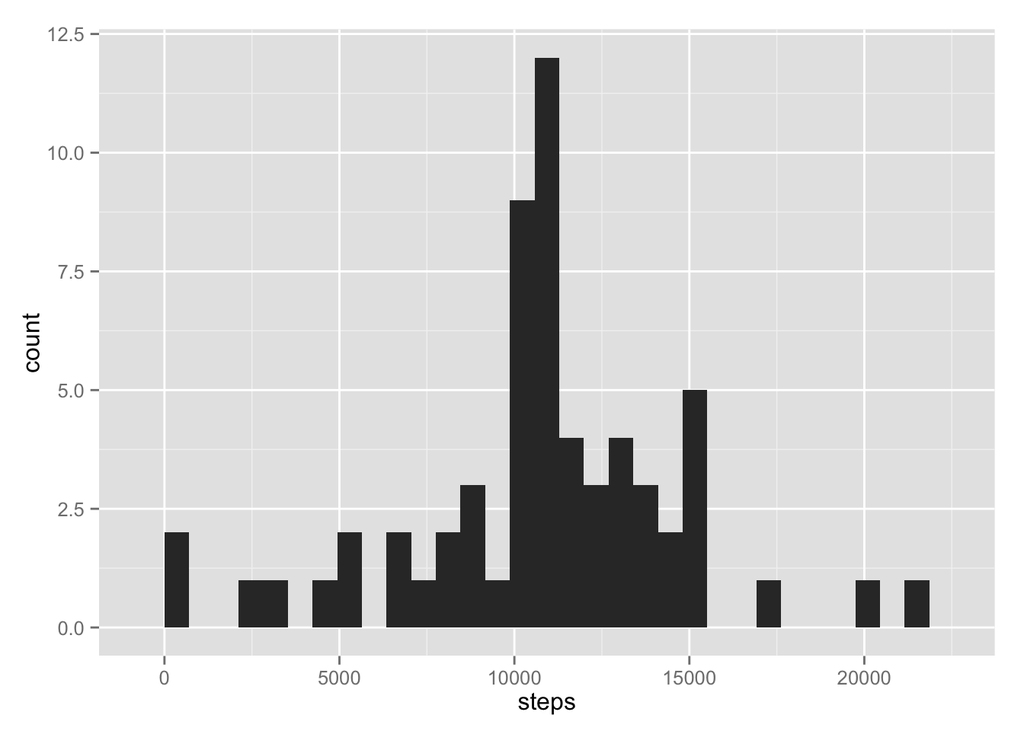

```r
data.fixed <- rbind(data.na, data)
daily.fixed <- aggregate(data.fixed$steps, list(data.fixed$date), sum, na.rm=TRUE)
names(daily.fixed) = c("date","steps")
p3 <- ggplot(daily.fixed, aes(x=steps))
p3 + geom_histogram()
```

4.The new mean of the total number of steps taken per day after missing values are imputed:

```r
mean(daily.fixed$steps)
```

```
## [1] 10766
```

The new median of the total number of steps taken per day after missing values are imputed:

```r
median(daily.fixed$steps)
```

```
## [1] 10766
```

The estimate is more or less the same as the estimates from the first assignment - the means are the same while the median shifted a little bit; it’s because we are just replacing empty values with the means for the imputed data set, so we should expect the mean should stay the same.

## Are there differences in activity patterns between weekdays and weekends?

The activity patterns between weekdays and weekends:

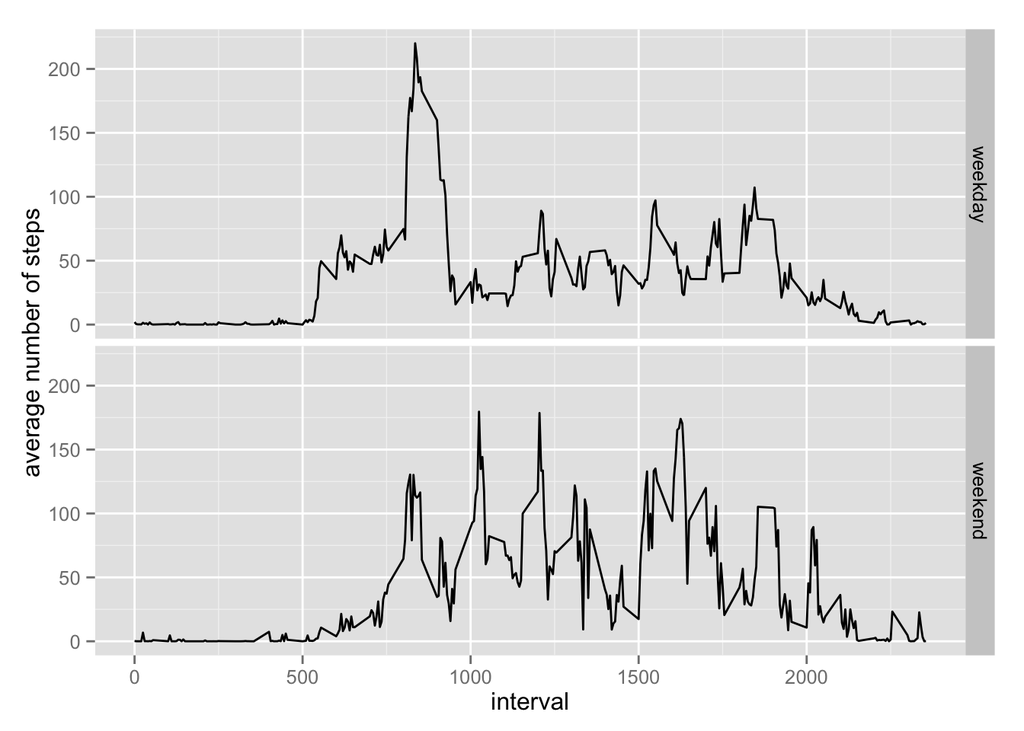

```r
days.of.week <- vector()

for (i in 1:nrow(data.fixed)) {
    date <- as.Date(data.fixed[i,]$date)
    weekday <- weekdays(date)

    if (weekday == "Sunday" | weekday == "Saturaday")
        days.of.week <- c(days.of.week, "weekend")
    else
        days.of.week <- c(days.of.week, "weekday")
}

data.fixed <- data.frame(data.fixed, days.of.week)
names(data.fixed)[4] = c("weekdays")

avg.steps.fixed <- aggregate(data.fixed$steps, list(data.fixed$interval, data.fixed$weekdays), mean, na.rm=TRUE)

names(avg.steps.fixed) = c("interval","weekdays", "steps")
p4 <- ggplot(avg.steps.fixed, aes(interval, steps))
p4 + geom_line() + xlab("interval") + ylab("average number of steps") + facet_grid(weekdays ~ .)
```